# ssigment - Naive Bayes DIY

Lachezar Popov - Author

31 March, 2021

```r
library(tidyverse)
library(tm)
library(caret)
library(wordcloud)
library(e1071)
```

Choose a suitable dataset from [this](https://github.com/HAN-M3DM-Data-Mining/assignments/tree/master/datasets) folder and train your own Naive Bayes model. Follow all the steps from the CRISP-DM model.

**Chosen dataset**: Fake News

## Data Understanding

The dataset was retrived from Kaggle, which is a community-maintained repository for public dataset. The data is comprised of news articles (the instances) along with labels for those articles (trustworthy or not) and a few other variables.

First we will look at the first 10 rows of the dataset to get a better understanding of the data.

```r
fakeNews_url = 'https://raw.githubusercontent.com/HAN-M3DM-Data-Mining/assignments/master/datasets/NB-fakenews.csv'
rawDF = read_csv(fakeNews_url)
head(rawDF, 10)
```

| id | title | author | text | label |
| --- | --- | --- | --- | --- |
| 0 | House Dem Aide: We Didn’t Even See Comey’s Letter Until Jason Chaffetz Tweeted It | Darrell Lucus | House Dem Aide: We Didn’t Even See Comey’s Letter Until Jason Chaffetz Tweeted It By Darrell Lucus on October 30, 2016 Subscribe Jason Chaffetz on the stump in American Fork, Utah ( image courtesy Mic… | 1 |
| 1 | FLYNN: Hillary Clinton, Big Woman on Campus - Breitbart | Daniel J. Flynn | Ever get the feeling your life circles the roundabout rather than heads in a straight line toward the intended destination? [Hillary Clinton remains the big woman on campus in leafy, liberal Wellesley… | 0 |
| 2 | Why the Truth Might Get You Fired | Consortiumnews.com | Why the Truth Might Get You Fired October 29, 2016 \nThe tension between intelligence analysts and political policymakers has always been between honest assessments and desired results, with the latte… | 1 |
| 3 | 15 Civilians Killed In Single US Airstrike Have Been Identified | Jessica Purkiss | Videos 15 Civilians Killed In Single US Airstrike Have Been Identified The rate at which civilians are being killed by American airstrikes in Afghanistan is now higher than it was in 2014 when the US … | 1 |
| 4 | Iranian woman jailed for fictional unpublished story about woman stoned to death for adultery | Howard Portnoy | Print \nAn Iranian woman has been sentenced to six years in prison after Iran’s Revolutionary Guard searched her home and found a notebook that contained a fictional story she’d written about a woman … | 1 |
| 5 | Jackie Mason: Hollywood Would Love Trump if He Bombed North Korea over Lack of Trans Bathrooms (Exclusive Video) - Breitbart | Daniel Nussbaum | In these trying times, Jackie Mason is the Voice of Reason. [In this week’s exclusive clip for Breitbart News, Jackie discusses the looming threat of North Korea, and explains how President Donald Tru… | 0 |
| 6 | Life: Life Of Luxury: Elton John’s 6 Favorite Shark Pictures To Stare At During Long, Transcontinental Flights | nan | Ever wonder how Britain’s most iconic pop pianist gets through a long flight? Here are the six pictures of sharks Sir Elton John likes to stare at to pass the time on an airplane. 1. A Shark Swimming … | 1 |
| 7 | Benoît Hamon Wins French Socialist Party’s Presidential Nomination - The New York Times | Alissa J. Rubin | PARIS — France chose an idealistic, traditional candidate in Sunday’s primary to represent the Socialist and parties in the presidential election this spring. The candidate, Benoît Hamon, 49, who ran … | 0 |
| 8 | Excerpts From a Draft Script for Donald Trump’s Q&ampA With a Black Church’s Pastor - The New York Times | nan | Donald J. Trump is scheduled to make a highly anticipated visit to an church in Detroit on Saturday, the first such visit of his campaign. There, he will participate in a session conducted by Bishop W… | 0 |
| 9 | A Back-Channel Plan for Ukraine and Russia, Courtesy of Trump Associates - The New York Times | Megan Twohey and Scott Shane | A week before Michael T. Flynn resigned as national security adviser, a sealed proposal was to his office, outlining a way for President Trump to lift sanctions against Russia. Mr. Flynn is gone, havi… | 0 |

We can see that the dataset has five columns. The labels are market with 1 (unreliable) and 0 (reliable). The other variables are the ID of the article (numeric), title (character), author (character) and the content of the aricle in the text column (character).

In the summary of the dataframe we can see that there are 20800 observations.

```r
summary(rawDF)
```

```
       id           title              author              text               label
 Min.   :    0   Length:20800       Length:20800       Length:20800       Min.   :0.0000
 1st Qu.: 5200   Class :character   Class :character   Class :character   1st Qu.:0.0000
 Median :10400   Mode  :character   Mode  :character   Mode  :character   Median :1.0000
 Mean   :10400                                                            Mean   :0.5006
 3rd Qu.:15599                                                            3rd Qu.:1.0000
 Max.   :20799                                                            Max.   :1.0000
```

Let us also examine the most commonly occuring words in reliable and unreliable articles through a wordcloud.

```
transformation drops documentstransformation drops documents
```

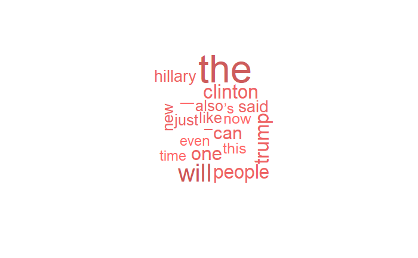

```r
unreliable = rawDF %>% filter(label == 1)
reliable = rawDF %>% filter(label == 0)

wordcloud(unreliable$text, max.words = 20, scale = c(4, 0.8), colors= c("indianred1","indianred2","indianred3","indianred"))
```

[output not shown]

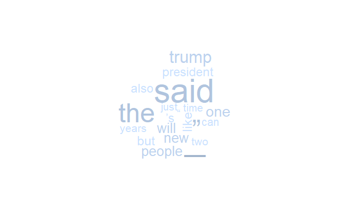

```r
wordcloud(reliable$text, max.words = 20, scale = c(4, 0.8), colors= c("lightsteelblue1","lightsteelblue2","lightsteelblue3","lightsteelblue"))
```

The output produces some interesting results. For example, we can see that the word “trump” appears in both wordclouds. Most of the words, however, are generic and do not provide much information (e.g. “the”, “one”, “can”, “just”, etc.).